# Cyclistic Project - Data Analysis

```python
# Library to suppress warnings or deprecation notes
import warnings
warnings.filterwarnings('ignore')

# Libraries to help with reading and manipulating data
import numpy as np
import pandas as pd

# Libraries to help with data visualization
import matplotlib.pyplot as plt
%matplotlib inline
import seaborn as sns
from numpy.polynomial.polynomial import polyfit

# Libraries to help build our Logistic Regression Model
from sklearn import metrics
from sklearn.metrics import accuracy_score,precision_score,recall_score,f1_score
from sklearn.metrics import confusion_matrix, classification_report
from sklearn.model_selection import train_test_split
from sklearn.tree import DecisionTreeClassifier
from sklearn import tree
from sklearn.model_selection import GridSearchCV
import statsmodels.api as sm

# libraries to help evaluate the model
from sklearn.metrics import roc_auc_score
from sklearn.metrics import roc_curve

#to ignore warnings
import warnings
warnings.filterwarnings('ignore')
```

```python
#Loading dataset 1
data = pd.read_excel("Post_Engineered.xlsx")
```

```python
Cleaned = pd.read_excel("Cleaned_Data.xlsx")
```

```python
Weekday = pd.read_excel("Weekday.xlsx")
```

```python
BD = data.copy() # This creates a copy of the dataframe
```

```python
BD.drop('Unnamed: 0',axis=1,inplace=True)
```

# Part 5: Univariate Analysis

We can now begin to perform Univariate Data Analysis to examine the frequencies, averages and other statistics of the individual variables. We will create definitions to help visualize the data using the next two blocks of code:

```python
def histogram_boxplot(data, xlabel=None, title=None, font_scale=2, figsize=(15,7), bins=None):
    mean = np.mean(data)

    sns.set(font_scale=font_scale) # setting the font scale of the seaborn
    f2, (ax_box2, ax_hist2) = plt.subplots(2, sharex=True, gridspec_kw={"height_ratios": (.25, .75)}, figsize=figsize)
    sns.boxplot(data, ax=ax_box2, showmeans=True,color="violet") #boxplot will be created and a star will indicate the mean value
    sns.distplot(data,kde=False, ax=ax_hist2, bins=bins,palette="winter") if bins else sns.distplot(data,kde=False, ax=ax_hist2, bins=None)
    ax_hist2.axvline(mean, color='g', linestyle='--') #mean will show as vertical line in the histogram
    if xlabel: ax_hist2.set(xlabel=xlabel) #xlabel
    if title: ax_box2.set(title=title) # title of the graph
    plt.show() # for plotting the graph
```

```python
def perc_on_bar(plot, feature):
    '''
    plot
    feature: categorical feature
    the function wont work if a colume is passed in hue parameter
    '''
    total = len(feature) # length of the column
    for p in ax.patches:
        percentage = '{:.1f}%'.format(100 * p.get_height()/total) # percentage of each class of the category
        x = p.get_x() + p.get_width() / 2 - 0.05 # width of the plot
        y = p.get_y() + p.get_height()           # height of the plot
        ax.annotate(percentage, (x,y), size = 20) # annotate the percentage
    plt.show() # shows the plot
```

```python
BD.head(1)
```

|  | member | started_at | ended_at | start_station_name | end_station_name | start_station_id | end_station_id | start_lat | end_lat | start_lng | ... | classic | docked | weekday | Day_Sunday | Day_Monday | Day_Tuesday | Day_Wednesday | Day_Thursday | Day_Friday | Day_Saturday |
| --- | --- | --- | --- | --- | --- | --- | --- | --- | --- | --- | --- | --- | --- | --- | --- | --- | --- | --- | --- | --- | --- |
| 0 | 1 | 2021-12-07 15:06:07 | 2021-12-07 15:13:42 | Laflin St & Cullerton St | Morgan St & Polk St | 13307 | TA1307000130 | 41.854833 | 41.871969 | -87.66366 | ... | 0 | 0 | Tuesday | 0 | 0 | 1 | 0 | 0 | 0 | 0 |

1 rows × 29 columns

### Member

The member variable is the dependent (y) variable for logistic regression. In other words, we want to examine how the other variables affect the member variable. It is in binary format, meaning there are only two values: member (1) or casual (0). Let's plot the frequencies of the two values.

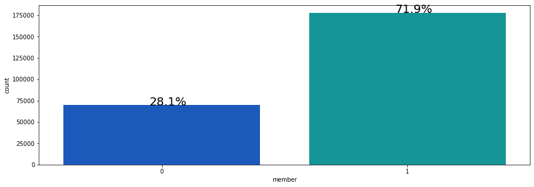

```python
plt.figure(figsize=(15,5))
ax = sns.countplot(BD['member'], palette='winter')
perc_on_bar(ax,BD['member'])
```

- We can see that there is almost 2.5 times more members than casual riders.

### Duration in Seconds

```python
BD.duration_in_s.describe()
```

```
count    2.473960e+05
mean     8.265854e+02
std      6.635566e+03
min      0.000000e+00
25%      2.980000e+02
50%      5.060000e+02
75%      8.830000e+02
max      1.824033e+06
Name: duration_in_s, dtype: float64
```

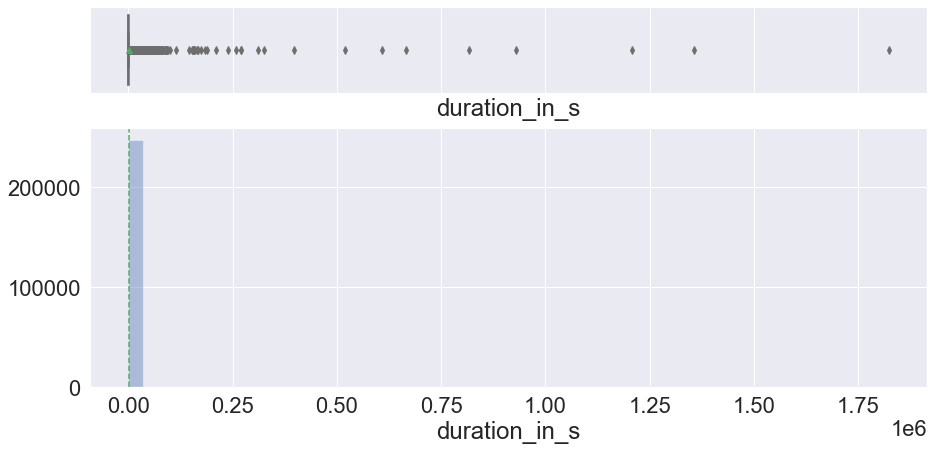

```python
histogram_boxplot(BD['duration_in_s'])
```

```python
median = np.median(BD.duration_in_s) # find the median income of all customers
mean = np.mean(BD.duration_in_s) # find the mean income of all customers
print('The mean equals', mean)
print('The median equals', median)
```

```
The mean equals 826.5854015424663
The median equals 506.0
```

- the data is not normally distributed
- since the mean is greater than the median, there is positive skewness
- there are a fair number of outliers; for our analysis we could probably ignore any value greater than 0.15 t0 0.20 x 1e6

### Ride Type

For the ride type, we can examine the Cleaned data so that we can see the frequencies of the three different types together.

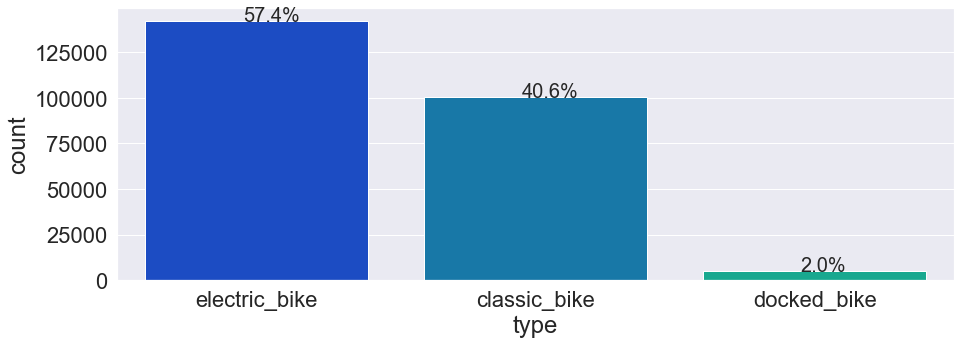

```python
plt.figure(figsize=(15,5))
ax = sns.countplot(Cleaned['type'], palette='winter')
perc_on_bar(ax,Cleaned['type'])
```

- We can see that electric bikes account for almost 60% of all bikes
- Classic bikes account for just over 40%
- Docked bikes account for only 2%
- This can be brought to the client's attention: if docked bikes do not have a very high profit margin, it might make more sense to discontinue this line of product.

### Weekday

For the Weekday value, we can examine the Weekday data so that we can see the frequencies of the seven different types together.

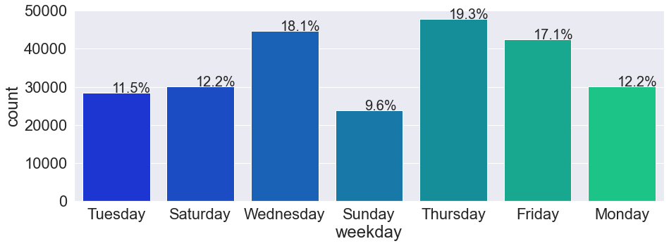

```python
plt.figure(figsize=(15,5))
ax = sns.countplot(Weekday['weekday'], palette='winter')
perc_on_bar(ax,Weekday['weekday'])
```

### Distance

```python
BD.Distance.describe()
```

```
count    247396.000000
mean          1.916958
std           1.783085
min           0.000000
25%           0.827766
50%           1.386808
75%           2.437556
max          23.629274
Name: Distance, dtype: float64
```

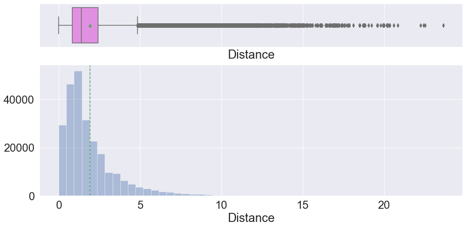

```python
histogram_boxplot(BD['Distance'])
```

```python
median = np.median(BD.Distance) # find the median income of all customers
mean = np.mean(BD.Distance) # find the mean income of all customers
print('The mean equals', mean)
print('The median equals', median)
```

```
The mean equals 1.9169584189340623
The median equals 1.386808167039131
```

- the data is not normally distributed
- since the mean is greater than the median, there is positive skewness
- there are a fair number of outliers, however riding a bike for more than 20km but less than 30km seems reasonable, especially considering there is an electric bike option.

# Part 6: Additional Data Processing

### Dealing with Outliers

#### Duration

After the multivariate analysis, we have discovered that there are a fair number of outliers in the duration_in_s variable. This means that there are several instances where the user took the rental bike for a much longer period than is normal. Due to the scale, it is hard to discern the exact point, visually, where the outliers begin. We can apply the formula 1.5 x IQR to find the exact point. We can also use the Days data to see if we can visually find the point. Let's try that first...

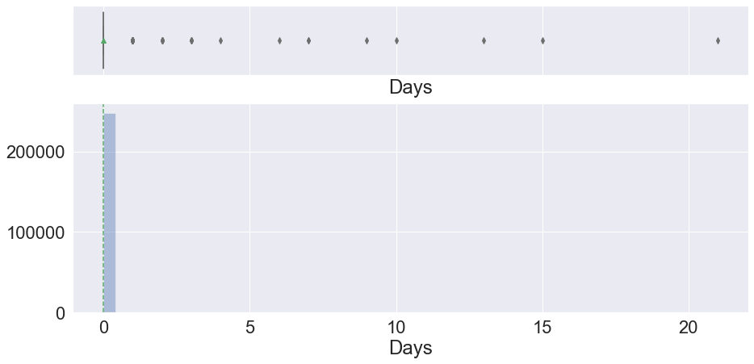

```python
histogram_boxplot(BD['Days'])
```

As we can see, anything greater than or equal to 1 day is considered an outlier. We can see from above that we have outliers ranging from 1 to 21 days, but each point may represent more than one instance. Lets do a quick count to see how many outliers there really are.

```python
counter = 0

for index in range(0, len(BD)):
    if BD['Days'].loc[index] >= 1 :
        counter = counter + 1


print('There are', counter, 'outliers')
```

```
There are 41 outliers
```

41 outliers is a small enough number, especially in comparison to the total number of rows. We can call these instances and examine them visually.

```python
BD.loc[BD['Days'] >= 1 ] #examining outliers beyond right whisker 1 day
```

|  | member | started_at | ended_at | start_station_name | end_station_name | start_station_id | end_station_id | start_lat | end_lat | start_lng | ... | classic | docked | weekday | Day_Sunday | Day_Monday | Day_Tuesday | Day_Wednesday | Day_Thursday | Day_Friday | Day_Saturday |
| --- | --- | --- | --- | --- | --- | --- | --- | --- | --- | --- | --- | --- | --- | --- | --- | --- | --- | --- | --- | --- | --- |
| 7422 | 0 | 2021-12-08 21:57:51 | 2021-12-09 22:57:45 | California Ave & Lake St | California Ave & Lake St | 15666 | 15666 | 41.884454 | 41.884454 | -87.696298 | ... | 1 | 0 | Wednesday | 0 | 0 | 0 | 1 | 0 | 0 | 0 |
| 12549 | 0 | 2021-12-23 15:19:41 | 2021-12-27 09:33:07 | Adler Planetarium | Adler Planetarium | 13431 | 13431 | 41.866095 | 41.866095 | -87.607267 | ... | 0 | 1 | Thursday | 0 | 0 | 0 | 0 | 1 | 0 | 0 |
| 14048 | 0 | 2021-12-25 03:06:59 | 2021-12-27 13:42:30 | Lawndale Ave & 111th St | Base - 2132 W Hubbard Warehouse | 20203 | Hubbard Bike-checking (LBS-WH-TEST) | 41.691319 | 41.889955 | -87.712886 | ... | 0 | 1 | Saturday | 0 | 0 | 0 | 0 | 0 | 0 | 1 |
| 14220 | 0 | 2021-12-16 18:07:34 | 2021-12-24 10:54:49 | Dearborn St & Erie St | Base - 2132 W Hubbard Warehouse | 13045 | Hubbard Bike-checking (LBS-WH-TEST) | 41.893992 | 41.889955 | -87.629318 | ... | 0 | 1 | Thursday | 0 | 0 | 0 | 0 | 1 | 0 | 0 |
| 14294 | 0 | 2021-12-11 03:14:03 | 2021-12-12 22:33:19 | Ashland Ave & Division St | Base - 2132 W Hubbard Warehouse | 13061 | Hubbard Bike-checking (LBS-WH-TEST) | 41.903450 | 41.889955 | -87.667747 | ... | 0 | 1 | Saturday | 0 | 0 | 0 | 0 | 0 | 0 | 1 |
| 14402 | 0 | 2021-12-12 15:52:31 | 2021-12-28 08:50:53 | Shedd Aquarium | Base - 2132 W Hubbard Warehouse | 15544 | Hubbard Bike-checking (LBS-WH-TEST) | 41.867226 | 41.889955 | -87.615355 | ... | 0 | 1 | Sunday | 1 | 0 | 0 | 0 | 0 | 0 | 0 |
| 14492 | 0 | 2021-12-31 10:40:31 | 2022-01-03 13:40:26 | Sacramento Blvd & Franklin Blvd | Base - 2132 W Hubbard Warehouse | KA1504000113 | Hubbard Bike-checking (LBS-WH-TEST) | 41.890469 | 41.889955 | -87.702608 | ... | 0 | 1 | Friday | 0 | 0 | 0 | 0 | 0 | 1 | 0 |
| 23436 | 0 | 2021-12-05 10:37:25 | 2021-12-07 13:46:46 | DuSable Lake Shore Dr & Monroe St | Clark St & Elmdale Ave | 13300 | KA1504000148 | 41.880958 | 41.990860 | -87.616743 | ... | 0 | 1 | Sunday | 1 | 0 | 0 | 0 | 0 | 0 | 0 |
| 27846 | 0 | 2021-12-14 03:00:53 | 2021-12-24 21:03:51 | South Chicago Ave & Elliot Ave | Dauphin Ave & 87th St | 665 | 20116 | 41.747363 | 41.736559 | -87.580046 | ... | 0 | 1 | Tuesday | 0 | 0 | 1 | 0 | 0 | 0 | 0 |
| 31623 | 0 | 2021-12-01 08:02:00 | 2021-12-22 10:42:33 | Central Ave & Lake St | California Ave & Milwaukee Ave | 16905 | 13084 | 41.887664 | 41.922695 | -87.765469 | ... | 0 | 1 | Wednesday | 0 | 0 | 0 | 1 | 0 | 0 | 0 |
| 32727 | 0 | 2021-12-10 14:33:48 | 2021-12-11 16:33:54 | Maplewood Ave & Peterson Ave | Maplewood Ave & Peterson Ave | KA1504000130 | KA1504000130 | 41.990236 | 41.990236 | -87.693370 | ... | 0 | 1 | Friday | 0 | 0 | 0 | 0 | 0 | 1 | 0 |
| 34108 | 0 | 2021-12-12 11:57:45 | 2021-12-14 09:44:20 | Milwaukee Ave & Grand Ave | Columbus Dr & Randolph St | 13033 | 13263 | 41.891578 | 41.884728 | -87.648384 | ... | 0 | 1 | Sunday | 1 | 0 | 0 | 0 | 0 | 0 | 0 |
| 35106 | 0 | 2021-12-29 12:32:22 | 2021-12-31 09:07:48 | Streeter Dr & Grand Ave | Michigan Ave & Pearson St | 13022 | 13034 | 41.892278 | 41.897660 | -87.612043 | ... | 0 | 1 | Wednesday | 0 | 0 | 0 | 1 | 0 | 0 | 0 |
| 35277 | 0 | 2021-12-17 19:14:37 | 2021-12-19 17:46:04 | Southport Ave & Wrightwood Ave | LaSalle St & Illinois St | TA1307000113 | 13430 | 41.928773 | 41.890762 | -87.663913 | ... | 0 | 1 | Friday | 0 | 0 | 0 | 0 | 0 | 1 | 0 |
| 39179 | 0 | 2021-12-15 19:48:03 | 2021-12-16 20:01:02 | Sedgwick St & Huron St | Wells St & Polk St | TA1307000062 | SL-011 | 41.894666 | 41.872596 | -87.638437 | ... | 1 | 0 | Wednesday | 0 | 0 | 0 | 1 | 0 | 0 | 0 |
| 48056 | 0 | 2021-12-08 11:52:27 | 2021-12-11 11:32:36 | Damen Ave & Madison St | Clark St & Ida B Wells Dr | 13134 | TA1305000009 | 41.881370 | 41.875933 | -87.674930 | ... | 0 | 1 | Wednesday | 0 | 0 | 0 | 1 | 0 | 0 | 0 |
| 48071 | 0 | 2021-12-27 22:21:59 | 2021-12-29 14:46:08 | McClurg Ct & Erie St | Clark St & Ida B Wells Dr | KA1503000041 | TA1305000009 | 41.894503 | 41.875933 | -87.617854 | ... | 0 | 1 | Monday | 0 | 1 | 0 | 0 | 0 | 0 | 0 |
| 49993 | 0 | 2021-12-08 23:21:37 | 2021-12-10 00:21:30 | Eckhart Park | Eckhart Park | 13289 | 13289 | 41.896373 | 41.896373 | -87.660984 | ... | 1 | 0 | Wednesday | 0 | 0 | 0 | 1 | 0 | 0 | 0 |
| 60539 | 0 | 2021-12-04 10:30:48 | 2021-12-06 15:11:09 | DuSable Lake Shore Dr & Monroe St | Fairbanks St & Superior St | 13300 | 18003 | 41.880958 | 41.895748 | -87.616743 | ... | 0 | 1 | Saturday | 0 | 0 | 0 | 0 | 0 | 0 | 1 |
| 62110 | 0 | 2021-12-19 14:26:48 | 2021-12-26 15:30:40 | Western Blvd & 48th Pl | May St & Cullerton St | 594 | 13331 | 41.805661 | 41.855136 | -87.683392 | ... | 0 | 1 | Sunday | 1 | 0 | 0 | 0 | 0 | 0 | 0 |
| 69351 | 0 | 2021-12-23 14:30:15 | 2021-12-25 15:16:53 | Wacker Dr & Washington St | Streeter Dr & Grand Ave | KA1503000072 | 13022 | 41.883143 | 41.892278 | -87.637242 | ... | 0 | 1 | Thursday | 0 | 0 | 0 | 0 | 1 | 0 | 0 |
| 69900 | 0 | 2021-12-06 12:22:54 | 2021-12-08 07:21:00 | New St & Illinois St | Streeter Dr & Grand Ave | TA1306000013 | 13022 | 41.890847 | 41.892278 | -87.618617 | ... | 0 | 1 | Monday | 0 | 1 | 0 | 0 | 0 | 0 | 0 |
| 72158 | 0 | 2021-12-10 08:44:10 | 2021-12-11 16:47:04 | Calumet Ave & 18th St | Shedd Aquarium | 13102 | 15544 | 41.857611 | 41.867226 | -87.619407 | ... | 0 | 1 | Friday | 0 | 0 | 0 | 0 | 0 | 1 | 0 |
| 100029 | 0 | 2021-12-23 02:11:40 | 2022-01-01 13:19:37 | Dearborn Pkwy & Delaware Pl | Michigan Ave & Washington St | TA1307000128 | 13001 | 41.898969 | 41.883984 | -87.629912 | ... | 0 | 1 | Thursday | 0 | 0 | 0 | 0 | 1 | 0 | 0 |
| 104988 | 0 | 2021-12-02 15:57:11 | 2021-12-16 15:41:18 | Damen Ave & Chicago Ave | Base - 2132 W Hubbard Warehouse | 13132 | Hubbard Bike-checking (LBS-WH-TEST) | 41.895769 | 41.889955 | -87.677220 | ... | 0 | 1 | Thursday | 0 | 0 | 0 | 0 | 1 | 0 | 0 |
| 105270 | 0 | 2021-12-26 09:27:49 | 2021-12-27 13:28:33 | Shore Dr & 55th St | Base - 2132 W Hubbard Warehouse | TA1308000009 | Hubbard Bike-checking (LBS-WH-TEST) | 41.795212 | 41.889955 | -87.580715 | ... | 0 | 1 | Sunday | 1 | 0 | 0 | 0 | 0 | 0 | 0 |
| 106944 | 0 | 2021-12-24 23:20:07 | 2021-12-26 17:49:21 | Ellis Ave & 58th St | Ellis Ave & 60th St | TA1309000011 | KA1503000014 | 41.788746 | 41.785097 | -87.601334 | ... | 0 | 1 | Friday | 0 | 0 | 0 | 0 | 0 | 1 | 0 |
| 109539 | 0 | 2021-12-01 08:10:11 | 2021-12-02 09:52:41 | Halsted St & 35th St | Halsted St & 35th St | TA1308000043 | TA1308000043 | 41.830661 | 41.830661 | -87.647172 | ... | 0 | 1 | Wednesday | 0 | 0 | 0 | 1 | 0 | 0 | 0 |
| 130732 | 0 | 2021-12-03 17:02:16 | 2021-12-07 07:39:37 | Wood St & Milwaukee Ave | Clinton St & Tilden St | 13221 | 13037 | 41.907655 | 41.875885 | -87.672552 | ... | 0 | 1 | Friday | 0 | 0 | 0 | 0 | 0 | 1 | 0 |
| 137494 | 0 | 2021-12-31 16:06:46 | 2022-01-01 18:39:37 | Warren Park West | Broadway & Argyle St | RP-001 | 13108 | 42.001785 | 41.973815 | -87.688829 | ... | 0 | 1 | Friday | 0 | 0 | 0 | 0 | 0 | 1 | 0 |
| 169780 | 0 | 2021-12-21 05:24:00 | 2021-12-25 19:28:02 | Larrabee St & Armitage Ave | Pulaski Rd & Congress Pkwy | TA1309000006 | 535 | 41.918084 | 41.874325 | -87.643749 | ... | 0 | 1 | Tuesday | 0 | 0 | 1 | 0 | 0 | 0 | 0 |
| 171153 | 0 | 2021-12-22 14:14:43 | 2021-12-25 17:07:04 | Shedd Aquarium | Buckingham Fountain | 15544 | 15541 | 41.867226 | 41.876535 | -87.615355 | ... | 0 | 1 | Wednesday | 0 | 0 | 0 | 1 | 0 | 0 | 0 |
| 171692 | 0 | 2021-12-19 16:49:38 | 2021-12-25 17:05:34 | Buckingham Fountain | Buckingham Fountain | 15541 | 15541 | 41.876535 | 41.876535 | -87.620473 | ... | 0 | 1 | Sunday | 1 | 0 | 0 | 0 | 0 | 0 | 0 |
| 173823 | 0 | 2021-12-04 16:28:04 | 2021-12-06 12:30:32 | Vernon Ave & 79th St | Vernon Ave & 79th St | 574 | 574 | 41.750940 | 41.750940 | -87.613790 | ... | 0 | 1 | Saturday | 0 | 0 | 0 | 0 | 0 | 0 | 1 |
| 197435 | 0 | 2021-12-31 12:07:56 | 2022-01-01 13:07:47 | State St & Randolph St | NaN | TA1305000029 | NaN | 41.884621 | 41.900000 | -87.627834 | ... | 1 | 0 | Friday | 0 | 0 | 0 | 0 | 0 | 1 | 0 |
| 198766 | 0 | 2021-12-31 22:58:06 | 2022-01-03 17:32:18 | LaSalle Dr & Huron St | Kingsbury St & Kinzie St | KP1705001026 | KA1503000043 | 41.894877 | 41.889177 | -87.632326 | ... | 0 | 1 | Friday | 0 | 0 | 0 | 0 | 0 | 1 | 0 |
| 199218 | 0 | 2021-12-04 15:04:17 | 2021-12-05 16:04:02 | Federal St & Polk St | NaN | SL-008 | NaN | 41.872078 | 41.870000 | -87.629544 | ... | 1 | 0 | Saturday | 0 | 0 | 0 | 0 | 0 | 0 | 1 |
| 201969 | 0 | 2021-12-24 18:08:26 | 2021-12-25 19:08:20 | Ashland Ave & Division St | NaN | 13061 | NaN | 41.903450 | 41.900000 | -87.667747 | ... | 1 | 0 | Friday | 0 | 0 | 0 | 0 | 0 | 1 | 0 |
| 203210 | 1 | 2021-12-12 00:01:02 | 2021-12-13 01:00:51 | Michigan Ave & 14th St | NaN | TA1307000124 | NaN | 41.864059 | 41.840000 | -87.623727 | ... | 1 | 0 | Sunday | 1 | 0 | 0 | 0 | 0 | 0 | 0 |
| 210923 | 1 | 2021-12-04 16:05:27 | 2021-12-05 17:05:19 | Michigan Ave & Oak St | NaN | 13042 | NaN | 41.900960 | 41.930000 | -87.623777 | ... | 1 | 0 | Saturday | 0 | 0 | 0 | 0 | 0 | 0 | 1 |
| 235577 | 0 | 2021-12-22 00:30:11 | 2021-12-23 01:30:03 | Leavitt St & Belmont Ave | NaN | KA17018068 | NaN | 41.939354 | 41.930000 | -87.683282 | ... | 1 | 0 | Wednesday | 0 | 0 | 0 | 1 | 0 | 0 | 0 |

41 rows × 29 columns

One thing we notice right away is that 39/41 rows contain CASUAL users. We can also see that most of the outliers happen near the end of the week (Wed to Sunday). We can examine this more closely as well..

```python
Outliers = BD.loc[BD['Days'] >= 1 ] # creating a temporary dataframe of just the outliers
```

```python
Outliers.groupby('weekday').count().sort_values(by='Days', ascending = False) #sorting the outliers by weekday frequencies
```

| weekday | member | started_at | ended_at | start_station_name | end_station_name | start_station_id | end_station_id | start_lat | end_lat | start_lng | ... | electric | classic | docked | Day_Sunday | Day_Monday | Day_Tuesday | Day_Wednesday | Day_Thursday | Day_Friday | Day_Saturday |
| --- | --- | --- | --- | --- | --- | --- | --- | --- | --- | --- | --- | --- | --- | --- | --- | --- | --- | --- | --- | --- | --- |
| Friday | 10 | 10 | 10 | 10 | 8 | 10 | 8 | 10 | 10 | 10 | ... | 10 | 10 | 10 | 10 | 10 | 10 | 10 | 10 | 10 | 10 |
| Wednesday | 9 | 9 | 9 | 9 | 8 | 9 | 8 | 9 | 9 | 9 | ... | 9 | 9 | 9 | 9 | 9 | 9 | 9 | 9 | 9 | 9 |
| Sunday | 7 | 7 | 7 | 7 | 6 | 7 | 6 | 7 | 7 | 7 | ... | 7 | 7 | 7 | 7 | 7 | 7 | 7 | 7 | 7 | 7 |
| Saturday | 6 | 6 | 6 | 6 | 4 | 6 | 4 | 6 | 6 | 6 | ... | 6 | 6 | 6 | 6 | 6 | 6 | 6 | 6 | 6 | 6 |
| Thursday | 5 | 5 | 5 | 5 | 5 | 5 | 5 | 5 | 5 | 5 | ... | 5 | 5 | 5 | 5 | 5 | 5 | 5 | 5 | 5 | 5 |
| Monday | 2 | 2 | 2 | 2 | 2 | 2 | 2 | 2 | 2 | 2 | ... | 2 | 2 | 2 | 2 | 2 | 2 | 2 | 2 | 2 | 2 |
| Tuesday | 2 | 2 | 2 | 2 | 2 | 2 | 2 | 2 | 2 | 2 | ... | 2 | 2 | 2 | 2 | 2 | 2 | 2 | 2 | 2 | 2 |

7 rows × 28 columns

Now lets calculate the actual limit of the outliers using the formula 1.5 x IQR of the duration_by_s

```python
#calculate interquartile range of values in the 'points' column
q75, q25 = np.percentile(BD['duration_in_s'], [75 ,25])
iqr = q75 - q25

uw = 1.5 * iqr

#display the upper whisker of the boxplot, in other words, 1.5 x x IQR
uw
```

```
877.5
```

Now lets count how many outliers there actually are...

```python
counter = 0

for index in range(0, len(BD)):
    if BD['duration_in_s'].loc[index] >= 877.5 :
        counter = counter + 1


print('There are', counter, 'outliers')
```

```
There are 62409 outliers
```

As we can see, there are now 62,409 outliers, which becomes problematice because this represents over 25% of the entire data. We can also see that any rental over 14.63 minutes is considered an outlier by this method. At this point, we have to make a decision regarding whether we keep all outliers or whether we choose some other value. We already know that the data is not normally distributed and that there is positive skewness with a long tail to the right. The reason for choosing 1.5 for the whiskers is to get it close to the acceptable 3 standard deviations of a Guassian model, however, this assumes normal distribution. Therefore, choosing 1.5 will not help us much in this isntance. We can choose a larger number, such as 2 or even three. Or we can make a business-oriented decision, and exclude any values larger than one day. By doing this, we can focus on day-rentals. And then we have a different dataset for anything longer than 1 day, which in this case, is only 41 entries. Lets go ahead and drop anything where day >= 1 day (or duration_in_s >= 86,400)

First, we will create two copies of the dataframe BD. This allows us to have a savepoint if we need to go back. The two copies will be:

- DR: short for Day Rides, and include all trips shorter than 86,400 seconds
- LR: short for Long Rides and will only include trips that are equal to or longer than 86,400 seconds

```python
DR = BD.copy()
```

```python
LR = BD.copy()
```

```python
DR.drop(DR.loc[DR['duration_in_s'] >= 86400].index, inplace=True)
```

```python
DR.shape
```

```
(247355, 29)
```

```python
LR.drop(LR.loc[LR['duration_in_s'] < 86400].index, inplace=True)
```

```python
LR.shape
```

```
(41, 29)
```

We can re-run the histogram plot of the duration_in_s variable to see what the data looks like now....

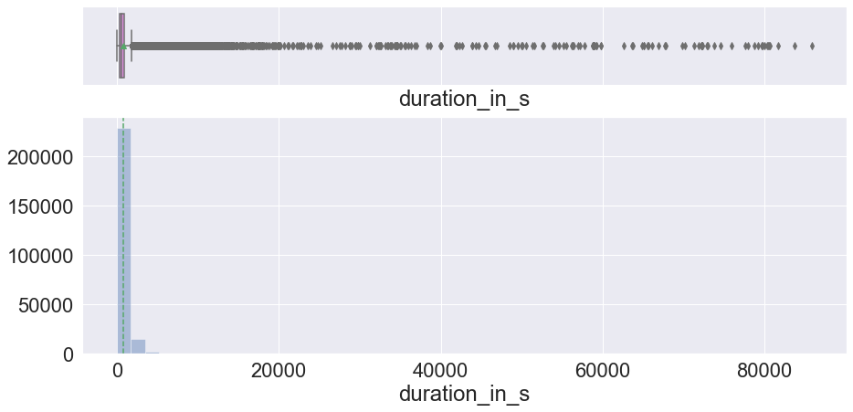

```python
histogram_boxplot(DR['duration_in_s'])
```

There are many outliers, but this is to be expected, since we already know that the whiskers only go to 877.5s and there was almost 62,000 points beyond this point. We can see that nothing goes past the 86,400s limit, which is equal to one day. These outliers are considered acceptable for our purposes, since it makes sense that users may rent a bike for an entire day, in some instances.

#### Distance

```python
counter = 0

for index in range(0, len(BD)):
    if BD['Distance'].loc[index] >= 20 :
        counter = counter + 1


print('There are', counter, 'trips greater than 20km')
```

```
There are 14 trips greater than 20km
```

14 outliers above 20km is a small enough number, especially in comparison to the total number of rows. We can call these instances and examine them visually.

```python
BD.loc[BD['Distance'] >= 20 ] #examining outliers beyond 20km
```

|  | member | started_at | ended_at | start_station_name | end_station_name | start_station_id | end_station_id | start_lat | end_lat | start_lng | ... | classic | docked | weekday | Day_Sunday | Day_Monday | Day_Tuesday | Day_Wednesday | Day_Thursday | Day_Friday | Day_Saturday |
| --- | --- | --- | --- | --- | --- | --- | --- | --- | --- | --- | --- | --- | --- | --- | --- | --- | --- | --- | --- | --- | --- |
| 7540 | 1 | 2021-12-19 12:33:47 | 2021-12-19 13:26:49 | Woodlawn Ave & Lake Park Ave | Broadway & Thorndale Ave | KA1503000065 | 15575 | 41.814064 | 41.989743 | -87.597020 | ... | 0 | 0 | Sunday | 1 | 0 | 0 | 0 | 0 | 0 | 0 |
| 14048 | 0 | 2021-12-25 03:06:59 | 2021-12-27 13:42:30 | Lawndale Ave & 111th St | Base - 2132 W Hubbard Warehouse | 20203 | Hubbard Bike-checking (LBS-WH-TEST) | 41.691319 | 41.889955 | -87.712886 | ... | 0 | 1 | Saturday | 0 | 0 | 0 | 0 | 0 | 0 | 1 |
| 27740 | 1 | 2021-12-23 16:08:31 | 2021-12-23 17:11:37 | LaSalle St & Adams St | Evanston Civic Center | KA1503000034 | 661 | 41.880095 | 42.057044 | -87.631886 | ... | 0 | 0 | Thursday | 0 | 0 | 0 | 0 | 1 | 0 | 0 |
| 27762 | 1 | 2021-12-14 17:27:58 | 2021-12-14 18:21:28 | Dearborn St & Adams St | Evanston Civic Center | TA1305000005 | 661 | 41.878984 | 42.057044 | -87.629409 | ... | 0 | 0 | Tuesday | 0 | 0 | 1 | 0 | 0 | 0 | 0 |
| 27766 | 1 | 2021-12-09 16:56:30 | 2021-12-09 17:53:31 | LaSalle St & Adams St | Evanston Civic Center | KA1503000034 | 661 | 41.879960 | 42.057044 | -87.631929 | ... | 0 | 0 | Thursday | 0 | 0 | 0 | 0 | 1 | 0 | 0 |
| 27784 | 1 | 2021-12-02 17:50:44 | 2021-12-02 18:52:54 | LaSalle St & Adams St | Evanston Civic Center | KA1503000034 | 661 | 41.879256 | 42.057219 | -87.632089 | ... | 0 | 0 | Thursday | 0 | 0 | 0 | 0 | 1 | 0 | 0 |
| 28287 | 1 | 2021-12-16 17:19:38 | 2021-12-16 18:21:20 | Dearborn St & Adams St | Evanston Civic Center | TA1305000005 | 661 | 41.879173 | 42.057044 | -87.629417 | ... | 0 | 0 | Thursday | 0 | 0 | 0 | 0 | 1 | 0 | 0 |
| 39686 | 1 | 2021-12-19 15:52:29 | 2021-12-19 16:58:33 | Clark St & Berwyn Ave | Dorchester Ave & 49th St | KA1504000146 | KA1503000069 | 41.978020 | 41.805772 | -87.667950 | ... | 0 | 0 | Sunday | 1 | 0 | 0 | 0 | 0 | 0 | 0 |
| 64800 | 0 | 2021-12-27 11:30:08 | 2021-12-27 13:21:35 | Museum of Science and Industry | California Ave & Byron St | KA1503000074 | 15628 | 41.791728 | 41.952162 | -87.583945 | ... | 0 | 1 | Monday | 0 | 1 | 0 | 0 | 0 | 0 | 0 |
| 91125 | 0 | 2021-12-30 16:16:18 | 2021-12-30 17:57:24 | Central St & Girard Ave | Field Blvd & South Water St | E007 | 15534 | 42.064305 | 41.886349 | -87.686104 | ... | 0 | 0 | Thursday | 0 | 0 | 0 | 0 | 1 | 0 | 0 |
| 92189 | 0 | 2021-12-30 16:07:35 | 2021-12-30 17:57:21 | Central St Metra | Field Blvd & South Water St | E006 | 15534 | 42.063819 | 41.886349 | -87.698654 | ... | 0 | 0 | Thursday | 0 | 0 | 0 | 0 | 1 | 0 | 0 |
| 126540 | 0 | 2021-12-14 10:59:35 | 2021-12-14 13:46:44 | Wood St & 35th St | Chicago Ave & Washington St | KA1503000066 | E002 | 41.830105 | 42.032562 | -87.670298 | ... | 1 | 0 | Tuesday | 0 | 0 | 1 | 0 | 0 | 0 | 0 |
| 235085 | 0 | 2021-12-25 10:22:39 | 2021-12-25 14:28:56 | Western Ave & 111th St | NaN | 20205 | NaN | 41.691209 | 41.480000 | -87.681308 | ... | 0 | 0 | Saturday | 0 | 0 | 0 | 0 | 0 | 0 | 1 |
| 246984 | 0 | 2021-12-24 13:21:34 | 2021-12-24 14:41:11 | NaN | NaN | NaN | NaN | 41.700000 | 41.890000 | -87.530000 | ... | 0 | 0 | Friday | 0 | 0 | 0 | 0 | 0 | 1 | 0 |

14 rows × 29 columns

One thing we notice right away is that most rows contain ELECTRIC type. We can also see that most of the outliers happen near the end of the week (Thurs to Sunday). We also know that the max distance is less than 24km, from .describe. Therefore, all of these outliers make sense and are acceptable. We will include these data points in our analysis.

### Simplfying the Datasets

Before we can run analysis, lets drop the variables that will not be used in the models. This is one of the reasons we made a copy of the dataset. Information such as started_at, ended_at, station names and ids, even the longitudes and latitudes, while helpful earlier, will not be used in the model and therefore are just cumbersome. So lets drop all unnessary columns before going forward.

```python
DR.drop('started_at',axis=1,inplace=True)
DR.drop('ended_at',axis=1,inplace=True)
DR.drop('end_station_id',axis=1,inplace=True)
DR.drop('start_station_id',axis=1,inplace=True)
DR.drop('end_station_name',axis=1,inplace=True)
DR.drop('start_station_name',axis=1,inplace=True)
DR.drop('start_lat',axis=1,inplace=True)
DR.drop('start_lng',axis=1,inplace=True)
DR.drop('end_lat',axis=1,inplace=True)
DR.drop('end_lng',axis=1,inplace=True)
DR.drop('Days',axis=1,inplace=True)
DR.drop('Hours',axis=1,inplace=True)
DR.drop('Minutes',axis=1,inplace=True)
DR.drop('Seconds',axis=1,inplace=True)
DR.drop('duration',axis=1,inplace=True)
DR.drop('weekday',axis=1,inplace=True)
```

```python
DR.isnull().sum() # this will tell us if there are missing values in an of the columns
```

```
member           0
Distance         0
duration_in_s    0
electric         0
classic          0
docked           0
Day_Sunday       0
Day_Monday       0
Day_Tuesday      0
Day_Wednesday    0
Day_Thursday     0
Day_Friday       0
Day_Saturday     0
dtype: int64
```

# Part 7: Bivariate/Multivariate Data Analysis

We can start by checking the correlation between the numerical data variables by using .corr and a heatmap function.

**Note:** we will be using the DR dataframe from now on...

```python
DR.corr() # creates a table of how the numerical values are correlated
```

|  | member | Distance | duration_in_s | electric | classic | docked | Day_Sunday | Day_Monday | Day_Tuesday | Day_Wednesday | Day_Thursday | Day_Friday | Day_Saturday |
| --- | --- | --- | --- | --- | --- | --- | --- | --- | --- | --- | --- | --- | --- |
| member | 1.000000 | -0.034627 | -0.129670 | -0.092165 | 0.156549 | -0.225963 | -0.052280 | 0.021651 | 0.049456 | 0.044311 | 0.019576 | -0.023769 | -0.071091 |
| Distance | -0.034627 | 1.000000 | 0.233787 | 0.088441 | -0.089244 | 0.000720 | 0.001286 | -0.002779 | -0.004184 | 0.002573 | 0.010618 | -0.006543 | -0.002601 |
| duration_in_s | -0.129670 | 0.233787 | 1.000000 | -0.067383 | 0.024172 | 0.154758 | 0.023672 | -0.002350 | -0.013010 | -0.016077 | -0.009127 | 0.001367 | 0.022040 |
| electric | -0.092165 | 0.088441 | -0.067383 | 1.000000 | -0.960482 | -0.164082 | -0.008551 | -0.009967 | -0.004684 | 0.002191 | 0.008807 | 0.010181 | -0.002690 |
| classic | 0.156549 | -0.089244 | 0.024172 | -0.960482 | 1.000000 | -0.116972 | 0.000134 | 0.011778 | 0.011970 | 0.003100 | -0.004916 | -0.011391 | -0.008161 |
| docked | -0.225963 | 0.000720 | 0.154758 | -0.164082 | -0.116972 | 1.000000 | 0.030037 | -0.006180 | -0.025710 | -0.018806 | -0.014000 | 0.004043 | 0.038518 |
| Day_Sunday | -0.052280 | 0.001286 | 0.023672 | -0.008551 | 0.000134 | 0.030037 | 1.000000 | -0.121651 | -0.117456 | -0.153290 | -0.159592 | -0.148426 | -0.121513 |
| Day_Monday | 0.021651 | -0.002779 | -0.002350 | -0.009967 | 0.011778 | -0.006180 | -0.121651 | 1.000000 | -0.134195 | -0.175136 | -0.182336 | -0.169579 | -0.138830 |
| Day_Tuesday | 0.049456 | -0.004184 | -0.013010 | -0.004684 | 0.011970 | -0.025710 | -0.117456 | -0.134195 | 1.000000 | -0.169097 | -0.176049 | -0.163732 | -0.134043 |
| Day_Wednesday | 0.044311 | 0.002573 | -0.016077 | 0.002191 | 0.003100 | -0.018806 | -0.153290 | -0.175136 | -0.169097 | 1.000000 | -0.229759 | -0.213684 | -0.174938 |
| Day_Thursday | 0.019576 | 0.010618 | -0.009127 | 0.008807 | -0.004916 | -0.014000 | -0.159592 | -0.182336 | -0.176049 | -0.229759 | 1.000000 | -0.222469 | -0.182129 |
| Day_Friday | -0.023769 | -0.006543 | 0.001367 | 0.010181 | -0.011391 | 0.004043 | -0.148426 | -0.169579 | -0.163732 | -0.213684 | -0.222469 | 1.000000 | -0.169387 |
| Day_Saturday | -0.071091 | -0.002601 | 0.022040 | -0.002690 | -0.008161 | 0.038518 | -0.121513 | -0.138830 | -0.134043 | -0.174938 | -0.182129 | -0.169387 | 1.000000 |

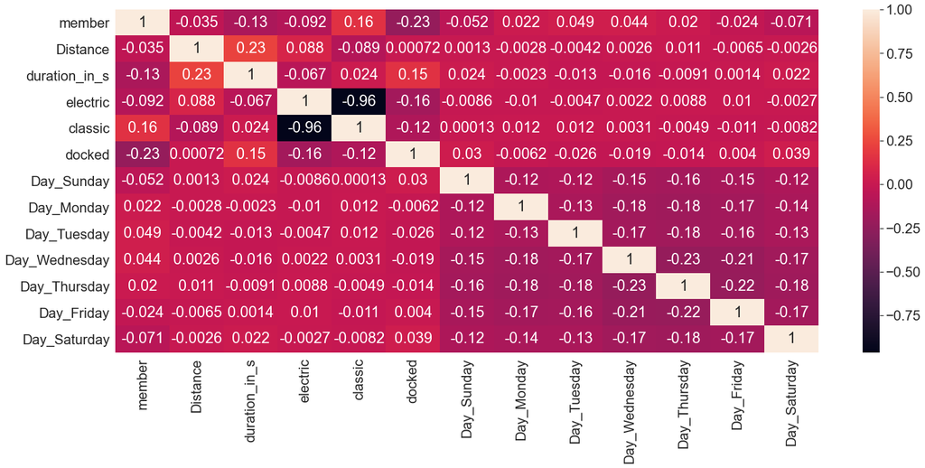

```python
plt.figure(figsize=(25,10))
sns.heatmap(DR.corr(), annot=True)
plt.show()
```

- If we define strong correlation as +/- 0.60 to 0.99, we can see that there are no strong correlations between the dependent variable and any other variable.
- If we define moderate correlation as +/- 0.25 to 0.59, we can see that there are no moderate correlations between the dependent variable and any other variable.
- If we define weak correlation as +/- 0.10 to 0.24 then docked and duration_in_s have weak negative correlations while classic has a weak positive correlation.
  - The only other correlation of note is that electric and classic are almost perfectly negatively correlated. This makes since, because in 98% of the cases, it is either one or the other.

```python
DR.to_excel('Daily_Rides_Only.xlsx', index = True)
```

```python
stop
```

[output not shown]

# Part 8: Building the Model

### What are we trying to determine?

**Recall or Precision?**

- Cyclistic can potentially face losses in one of two ways:
  - The company erroneously identifies a member as a casual rider and begins marketing to them to become a member (False Negative)
  - The company identifies a casual rider as a member and does not target them in the marketing campaign - Opportunity Loss (False Positive)

**Which loss is greater ?**

- Misidentifying a member as a casual rider may be insulting or annoying to the customer. They may not feel valued at all and take their business elsewhere. Cancelling their membership is worse than not targeting a casual rider because they may not purchase a membership regardless. There is also a cost to marketing to someone who is already a member. (False Negative)

**Decision**

- Recall - In this case, there is a high cost associated with a False Negative so we want to reduce the chances of a member being identified as a casual rider.
- Recall gives the ratio of True positives to Actual positives, so high Recall implies low false negatives, i.e. low chances of predicting a member as a casual customer.

## A) Logistic Regression - statsmodels

### Approach

1. Choose a Model
2. Split the Data and Train the Model
3. Evaluate the Model
4. Tune the Model and Prune the Tree (if required)
5. Check Performance

### 1. Choose a Model

For our first trial, we shall choose the statsmodel method of building a logistic regression model. This is a package in python that allows us to see the entire tree, using all the variables. This approach means that, generally, the model is overfitting the data and requires post-pruning. This can be done by checking for multicollinearity and dropping variables with insignificant p-values. The benefit of this method allows us to see all the variables within the model and how decisions are made, based on what the computer identifies as the importance of the variables. It is also a more hands-on approach, better suited to allow the user to really understand the independent variables and how they interact with the dependent variable.

### 2. Split the Data and Train the Model

```python
# Separating the dependent and independent variables into two dataframes
X = DR.drop('member', axis=1) #Dropping the dependent variable, Loan
Y = DR['member'] # establishing Loan as the dependent variable
```

We must remember that, the way onehotencoding works, is that one of the dummy variables should be dropped. For instance, in the days of the week, we can drop Saturday (or any day will do, but Saturday is the last one so we will drop that). The way the computer interprets this, is that if there are zeros for the six remaining variables (Sun-Fri), then it has to be the 'other'. In other words, saturday has become irrelevant. Simiarly, we will drop docked.

```python
X.drop('docked',axis=1,inplace=True)
X.drop('Day_Saturday',axis=1,inplace=True)
```

```python
# splitting in training and test set
X_train, X_test, y_train, y_test = train_test_split( X, Y, test_size = 0.3, random_state = 42)
```

**Fit logistic regression model (statsmodel)**

```python
import statsmodels.api as sm

# adding constant to training and test set
X_train = sm.add_constant(X_train)
X_test = sm.add_constant(X_test)

logit = sm.Logit( y_train, X_train )

lg = logit.fit()

print(lg.summary2())

# Let's Look at Model Performance
y_pred = lg.predict(X_train)
pred_train = list(map(round, y_pred))

y_pred1 = lg.predict(X_test)
pred_test = list(map(round, y_pred1))

print('recall on train data:',recall_score(y_train, pred_train) )
print('recall on test data:',recall_score(y_test, pred_test))
```

[output not shown]

### 3. Evaluate the Model

```python
from sklearn.metrics import classification_report,confusion_matrix


def make_confusion_matrix(y_actual,y_predict,labels=[1, 0]):
    '''
    y_predict: prediction of class
    y_actual : ground truth
    '''
    cm=confusion_matrix( y_predict,y_actual, labels=[1, 0])
    df_cm = pd.DataFrame(cm, index = [i for i in ["1","0"]],
                  columns = [i for i in ['1','0']])
    group_counts = ["{0:0.0f}".format(value) for value in
                cm.flatten()]
    group_percentages = ["{0:.2%}".format(value) for value in
                         cm.flatten()/np.sum(cm)]
    labels = [f"{v1}\n{v2}" for v1, v2 in
              zip(group_counts,group_percentages)]
    labels = np.asarray(labels).reshape(2,2)
    plt.figure(figsize = (7,5))
    sns.heatmap(df_cm, annot=labels,fmt='')
    plt.ylabel('True label')
    plt.xlabel('Predicted label')
```

```python
make_confusion_matrix(y_train,pred_train)
```

[output not shown]

```python
print('recall on train data:',recall_score(y_train, pred_train) )
print('recall on test data:',recall_score(y_test, pred_test))
```

[output not shown]

```python
from statsmodels.stats.outliers_influence import variance_inflation_factor
vif_series1 = pd.Series([variance_inflation_factor(X_train.values,i) for i in range(X_train.shape[1])],index=X_train.columns)
print('Series before feature selection: \n\n{}\n'.format(vif_series1))
```

[output not shown]

- We knew that electric and classic were almost perfectly negatively correlated, which is causing multicollinearity here.
- vis scores above ten show strong multicollinearity; while scores about 5 should not be accepted
- We will drop the lower scoring variable and re-run the model...

```python
# Dropping the ariable with the highest vif values and check the Adjusted-R Squared
X_train2 = X_train.drop('classic', axis=1)
vif_series2 = pd.Series([variance_inflation_factor(X_train2.values,i) for i in range(X_train2.shape[1])],index=X_train2.columns)
print('Series before feature selection: \n\n{}\n'.format(vif_series2))
```

[output not shown]

```python
X_test2 = X_test.drop('classic',axis =1)

logit1 = sm.Logit(y_train, X_train2 )
lg1 = logit1.fit()
print(lg1.summary2())

# Let's Look at Model Performance
y_pred = lg1.predict(X_train2)
pred_train = list(map(round, y_pred))

y_pred1 = lg1.predict(X_test2)
pred_test = list(map(round, y_pred1))

print('Recall on train data:',recall_score(y_train, pred_train) )
print('Recall on test data:',recall_score(y_test, pred_test))
```

[output not shown]

```python
make_confusion_matrix(y_train,pred_train)
```

[output not shown]

### 5. Check Model Performance

```python
# Let's Look at Model Performance
y_pred = lg1.predict(X_train2)
pred_train = list(map(round, y_pred))

y_pred1 = lg1.predict(X_test2)
pred_test = list(map(round, y_pred1))
```

```python
#Model performance with 0.5 threshold

print('Accuracy on train data:',accuracy_score(y_train, pred_train) )
print('Accuracy on test data:',accuracy_score(y_test, pred_test))
print('')
print('Recall on train data:',recall_score(y_train, pred_train) )
print('Recall on test data:',recall_score(y_test, pred_test))
print('')
print('Precision on train data:',precision_score(y_train, pred_train) )
print('Precision on test data:',precision_score(y_test, pred_test))
print('')
print('f1 score on train data:',f1_score(y_train, pred_train))
print('f1 score on test data:',f1_score(y_test, pred_test))
```

[output not shown]

```python
#AUC ROC curve
from sklearn.metrics import roc_auc_score
from sklearn.metrics import roc_curve

logit_roc_auc = roc_auc_score(y_test, lg1.predict(X_test2))
fpr, tpr, thresholds = roc_curve(y_test, lg1.predict(X_test2))
plt.figure(figsize=(13,8))
plt.plot(fpr, tpr, label='Logistic Regression (area = %0.2f)' % logit_roc_auc)
plt.plot([0, 1], [0, 1],'r--')
plt.xlim([0.0, 1.0])
plt.ylim([0.0, 1.05])
plt.xlabel('False Positive Rate')
plt.ylabel('True Positive Rate')
plt.title('Receiver operating characteristic')
plt.legend(loc="lower right")
plt.savefig('Log_ROC')
plt.show()
```

[output not shown]

### Odds

- When coefficient is b , then change in odds is (exp(b)-1)*100 %
- Probability = odd/(1+odd)

```python
odds=((np.exp(np.abs(lg1.params)))-1)
print(odds)
```

[output not shown]

### Coefficient interpretations

**Try to improve Recall using AUC-ROC curve**

```python
# Optimal threshold as per AUC-ROC curve
# The optimal cut off would be where tpr is high and fpr is low
fpr, tpr, thresholds = roc_curve(y_test, lg1.predict(X_test2))

optimal_idx = np.argmax(tpr - fpr)
optimal_threshold = thresholds[optimal_idx]
print(optimal_threshold)
```

[output not shown]

```python
#Model performance with optimal threhold

print('Accuracy on train data:',accuracy_score(y_train, pred_train_opt) )
print('Accuracy on test data:',accuracy_score(y_test, pred_test_opt))
print('')
print('Recall on train data:',recall_score(y_train, pred_train_opt))
print('Recall on test data:',recall_score(y_test, pred_test_opt))
print('')
print('Precision on train data:',precision_score(y_train, pred_train_opt) )
print('Precision on test data:',precision_score(y_test, pred_test_opt))
print('')
print('f1 score on train data:',f1_score(y_train, pred_train_opt))
print('f1 score on test data:',f1_score(y_test, pred_test_opt))
```

[output not shown]

**Precision-Recall curve to Find a Better Threshold**

```python
from sklearn.metrics import precision_recall_curve

y_scores=lg1.predict(X_train2)
prec, rec, tre = precision_recall_curve(y_train, y_scores, )

def plot_prec_recall_vs_tresh(precisions, recalls, thresholds):
    plt.plot(thresholds, precisions[:-1], 'b--', label='precision')
    plt.plot(thresholds, recalls[:-1], 'g--', label = 'recall')
    plt.xlabel('Threshold')
    plt.legend(loc='upper left')
    plt.ylim([0,1])

plot_prec_recall_vs_tresh(prec, rec, tre)
plt.show()
```

[output not shown]

**Check Model Performance**

```python
optimal_threshold = 0.60

# Model prediction with optimal threshold
pred_train_opt = (lg1.predict(X_train2)>optimal_threshold).astype(int)
pred_test_opt = (lg1.predict(X_test2)>optimal_threshold).astype(int)

#Model performance with optimal threhold

print('Accuracy on train data:',accuracy_score(y_train, pred_train_opt) )
print('Accuracy on test data:',accuracy_score(y_test, pred_test_opt))
print('')
print('Recall on train data:',recall_score(y_train, pred_train_opt))
print('Recall on test data:',recall_score(y_test, pred_test_opt))
print('')
print('Precision on train data:',precision_score(y_train, pred_train_opt) )
print('Precision on test data:',precision_score(y_test, pred_test_opt))
print('')
print('f1 score on train data:',f1_score(y_train, pred_train_opt))
print('f1 score on test data:',f1_score(y_test, pred_test_opt))
```

[output not shown]

**Confusion Matrix on Train Set**

```python
make_confusion_matrix(y_train,pred_train_opt)
```

[output not shown]

**Confusion Matrix on Test Set**

```python
make_confusion_matrix(y_test,pred_test_opt)
```

[output not shown]

# Decision Trees

## Split data

```python
X_train, X_test, y_train, y_test = train_test_split(X, Y, test_size=.30, random_state=1)
```

## Build Decision Tree Model

We will build our model using the DecisionTreeClassifier function. Using default 'gini' criteria to split. Other option include 'entropy'.

```python
X_train.columns
```

[output not shown]

```python
dTree = DecisionTreeClassifier(criterion = 'gini', random_state=1)
dTree.fit(X_train, y_train)
```

```python
prob_train = dTree.predict_proba(X_train)
pred_train = dTree.predict(X_train)

prob_test = dTree.predict_proba(X_test)
pred_test = dTree.predict(X_test)
```

```python
# let us make confusion matrix on train set
make_confusion_matrix(y_train,pred_train)
```

[output not shown]

```python
# let us make confusion matrix on test set
make_confusion_matrix(y_test,pred_test)
```

[output not shown]

```python
# Let's check model performances for this model
score_DT = get_metrics_score2(dTree,X_train,X_test,y_train,y_test,flag=True)
```

[output not shown]

## Visualizing the Decision Tree

```python
feature_names = list(X.columns)
print(feature_names)
```

[output not shown]

```python
# Text report showing the rules of a decision tree -

print(tree.export_text(dTree,feature_names=feature_names,show_weights=True))
```

[output not shown]

```python
# importance of features in the tree building ( The importance of a feature is computed as the
#(normalized) total reduction of the criterion brought by that feature. It is also known as the Gini importance )

print (pd.DataFrame(dTree.feature_importances_, columns = ["Imp"], index = X_train.columns).sort_values(by = 'Imp', ascending = False))
```

[output not shown]

```python
importances = dTree.feature_importances_
indices = np.argsort(importances)

plt.figure(figsize=(8,8))
plt.title('Feature Importances')
plt.barh(range(len(indices)), importances[indices], color='violet', align='center')
plt.yticks(range(len(indices)), [feature_names[i] for i in indices])
plt.xlabel('Relative Importance')
plt.show()
```

[output not shown]